# Carto coding exercise

Yang Cai

May 30, 2019

# Load libraries and datasets

```r
#load libraries
if (!require("tidyverse")) install.packages("tidyverse");library(tidyverse)
if (!require("ggplot2")) install.packages("ggplot2");library(ggplot2)
if (!require("data.table")) install.packages("data.table");library(data.table)
if (!require("lubridate")) install.packages("lubridate");library(lubridate)
if (!require("gridExtra")) install.packages("gridExtra");library(gridExtra)
if (!require("DT")) install.packages("DT");library(DT)
if (!require("caret")) install.packages("caret");library(caret)
if (!require("ggcorrplot")) install.packages("ggcorrplot");library(ggcorrplot)
if (!require("knitr")) install.packages("knitr");library(knitr)
#load datasets
trip_3 <-fread("./data/yellow_tripdata_2017-03.csv")
trip_6 <- fread("./data/yellow_tripdata_2017-06.csv")
trip_11 <- fread("./data/yellow_tripdata_2017-11.csv")
```

# Data exploration and cleaning

## Data preprocessing

First, we need to combine these 3 datasets into one and add a column named ‘month’ to distinguish between different months (March, June, Nov).

```r
trip_3$month <- "Mar"
trip_6$month <- "June"
trip_11$month <- "Nov"
trip <- rbind(trip_3,trip_6,trip_11)
```

```r
#summary statistics
kable(summary(trip)[,1:5])
```

|  | VendorID | tpep_pickup_datetime | tpep_dropoff_datetime | passenger_count | trip_distance |
| --- | --- | --- | --- | --- | --- |
|  | Min. :1.000 | Length:3145722 | Length:3145722 | Min. :0.000 | Min. : 0.000 |
|  | 1st Qu.:1.000 | Class :character | Class :character | 1st Qu.:1.000 | 1st Qu.: 0.980 |
|  | Median :2.000 | Mode :character | Mode :character | Median :1.000 | Median : 1.600 |
|  | Mean :1.503 | NA | NA | Mean :1.585 | Mean : 2.857 |
|  | 3rd Qu.:2.000 | NA | NA | 3rd Qu.:2.000 | 3rd Qu.: 3.000 |
|  | Max. :2.000 | NA | NA | Max. :9.000 | Max. :598.500 |

```r
kable(summary(trip)[,6:11])
```

|  | RatecodeID | store_and_fwd_flag | PULocationID | DOLocationID | payment_type | fare_amount |
| --- | --- | --- | --- | --- | --- | --- |
|  | Min. : 1.000 | Length:3145722 | Min. : 1.0 | Min. : 1.0 | Min. :1.000 | Min. :-190.00 |
|  | 1st Qu.: 1.000 | Class :character | 1st Qu.:114.0 | 1st Qu.:107.0 | 1st Qu.:1.000 | 1st Qu.: 6.50 |
|  | Median : 1.000 | Mode :character | Median :162.0 | Median :162.0 | Median :1.000 | Median : 9.50 |
|  | Mean : 1.041 | NA | Mean :163.5 | Mean :161.3 | Mean :1.322 | Mean : 12.97 |
|  | 3rd Qu.: 1.000 | NA | 3rd Qu.:233.0 | 3rd Qu.:233.0 | 3rd Qu.:2.000 | 3rd Qu.: 15.00 |
|  | Max. :99.000 | NA | Max. :265.0 | Max. :265.0 | Max. :5.000 | Max. :8018.00 |

```r
kable(summary(trip)[,12:18])
```

|  | extra | mta_tax | tip_amount | tolls_amount | improvement_surcharge | total_amount | month |
| --- | --- | --- | --- | --- | --- | --- | --- |
|  | Min. :-50.5600 | Min. : -0.5000 | Min. :-22.900 | Min. : -5.7600 | Min. :-0.3000 | Min. :-190.80 | Length:3145722 |
|  | 1st Qu.: 0.0000 | 1st Qu.: 0.5000 | 1st Qu.: 0.000 | 1st Qu.: 0.0000 | 1st Qu.: 0.3000 | 1st Qu.: 8.80 | Class :character |
|  | Median : 0.5000 | Median : 0.5000 | Median : 1.450 | Median : 0.0000 | Median : 0.3000 | Median : 12.30 | Mode :character |
|  | Mean : 0.4141 | Mean : 0.4974 | Mean : 1.879 | Mean : 0.3136 | Mean : 0.2997 | Mean : 16.38 | NA |
|  | 3rd Qu.: 0.5000 | 3rd Qu.: 0.5000 | 3rd Qu.: 2.460 | 3rd Qu.: 0.0000 | 3rd Qu.: 0.3000 | 3rd Qu.: 18.30 | NA |
|  | Max. : 69.8000 | Max. :140.0000 | Max. :444.000 | Max. :923.5000 | Max. : 1.0000 | Max. :8018.80 | NA |

### Removing duplicates

After checking the summary statistics for the three datasets, there are no values missing. I also checked for duplicates (duplicated rows) and deleted them.

```r
trip_new <- trip[-which(duplicated(trip)),]
```

### Converting columns

Then we need to convert the pickup and dropoff column into datetime types. We can also derive a column that describes the trip duration from the time difference between pickup and dropoff.

Besides the duration column, we can also add columns that describe pickup hour, pickup day of the week and peekup day of the month. I named them as pickup_hour, weekday and day.

```r
trip_new$tpep_pickup_datetime <- mdy_hm(trip_new$tpep_pickup_datetime)
trip_new$tpep_dropoff_datetime <- mdy_hm(trip_new$tpep_dropoff_datetime)
trip_new <- trip_new %>%
  mutate(duration = difftime(tpep_dropoff_datetime,tpep_pickup_datetime,
                             units = "mins")) #here we added the time duration of trip (min) column to the dataset
trip_new$duration <- as.numeric(trip_new$duration)
trip_new <- trip_new %>% mutate(pickup_hour = hour(tpep_pickup_datetime),
                                weekday = weekdays(tpep_pickup_datetime),
                                day = day(tpep_pickup_datetime)) #add columns of pickup hour, pickup day of week and day of the month
```

### Factoring specific columns

Some columns need to be factored: VendorID, RatecodeID, Store_and_fwd_flag, payment_type, month and weekday. So we need to factor these columns for each dataset.

```r
trip_new <- mutate_each(trip_new,list(factor),c(VendorID,RatecodeID,store_and_fwd_flag,payment_type,month,weekday))
```

Because we have added new columns to the dataset and also converted columns into correct data types, we need to inspect the summary statistics again to see if there are additional findings.

### Removing incorrect data

From the summary, I found that for the pickup and dropoff time, there might be incorrect date time (i.e. date that is not in 2017). Therefore, I will remove entries with date not in 2017.

```r
kable(summary(trip_new)[,1:5])
```

|  | VendorID | tpep_pickup_datetime | tpep_dropoff_datetime | passenger_count | trip_distance |
| --- | --- | --- | --- | --- | --- |
|  | 1:1563958 | Min. :2008-12-31 17:48:00 | Min. :2008-12-31 17:57:00 | Min. :0.000 | Min. : 0.000 |
|  | 2:1581513 | 1st Qu.:2017-03-10 20:27:00 | 1st Qu.:2017-03-10 20:40:00 | 1st Qu.:1.000 | 1st Qu.: 0.980 |
|  | NA | Median :2017-06-02 15:08:00 | Median :2017-06-02 15:29:00 | Median :1.000 | Median : 1.600 |
|  | NA | Mean :2017-06-25 00:00:04 | Mean :2017-06-25 00:16:43 | Mean :1.585 | Mean : 2.857 |
|  | NA | 3rd Qu.:2017-11-01 20:05:00 | 3rd Qu.:2017-11-01 20:20:30 | 3rd Qu.:2.000 | 3rd Qu.: 3.000 |
|  | NA | Max. :2017-11-04 23:51:00 | Max. :2017-11-05 02:33:00 | Max. :9.000 | Max. :598.500 |
|  | NA | NA | NA | NA | NA |

```r
kable(summary(trip_new)[,6:11])
```

|  | RatecodeID | store_and_fwd_flag | PULocationID | DOLocationID | payment_type | fare_amount |
| --- | --- | --- | --- | --- | --- | --- |
|  | 1 :3063766 | N:3131164 | Min. : 1.0 | Min. : 1.0 | 1:2159619 | Min. :-190.00 |
|  | 2 : 63648 | Y: 14307 | 1st Qu.:114.0 | 1st Qu.:107.0 | 2: 962641 | 1st Qu.: 6.50 |
|  | 3 : 6196 | NA | Median :162.0 | Median :162.0 | 3: 18201 | Median : 9.50 |
|  | 4 : 1593 | NA | Mean :163.5 | Mean :161.3 | 4: 5009 | Mean : 12.97 |
|  | 5 : 10176 | NA | 3rd Qu.:233.0 | 3rd Qu.:233.0 | 5: 1 | 3rd Qu.: 15.00 |
|  | 6 : 24 | NA | Max. :265.0 | Max. :265.0 | NA | Max. :8018.00 |
|  | 99: 68 | NA | NA | NA | NA | NA |

```r
kable(summary(trip_new)[,12:17])
```

|  | extra | mta_tax | tip_amount | tolls_amount | improvement_surcharge | total_amount |
| --- | --- | --- | --- | --- | --- | --- |
|  | Min. :-50.5600 | Min. : -0.5000 | Min. :-22.900 | Min. : -5.7600 | Min. :-0.3000 | Min. :-190.80 |
|  | 1st Qu.: 0.0000 | 1st Qu.: 0.5000 | 1st Qu.: 0.000 | 1st Qu.: 0.0000 | 1st Qu.: 0.3000 | 1st Qu.: 8.80 |
|  | Median : 0.5000 | Median : 0.5000 | Median : 1.450 | Median : 0.0000 | Median : 0.3000 | Median : 12.30 |
|  | Mean : 0.4141 | Mean : 0.4974 | Mean : 1.879 | Mean : 0.3137 | Mean : 0.2997 | Mean : 16.38 |
|  | 3rd Qu.: 0.5000 | 3rd Qu.: 0.5000 | 3rd Qu.: 2.460 | 3rd Qu.: 0.0000 | 3rd Qu.: 0.3000 | 3rd Qu.: 18.30 |
|  | Max. : 69.8000 | Max. :140.0000 | Max. :444.000 | Max. :923.5000 | Max. : 1.0000 | Max. :8018.80 |
|  | NA | NA | NA | NA | NA | NA |

```r
kable(summary(trip_new[,18:22]))
```

|  | month | duration | pickup_hour | weekday | day |
| --- | --- | --- | --- | --- | --- |
|  | June:1048475 | Min. : 0.00 | Min. : 0.00 | Friday : 958567 | Min. : 1.000 |
|  | Mar :1048504 | 1st Qu.: 7.00 | 1st Qu.: 9.00 | Saturday : 415231 | 1st Qu.: 1.000 |
|  | Nov :1048492 | Median : 12.00 | Median :15.00 | Sunday : 45240 | Median : 2.000 |
|  | NA | Mean : 16.64 | Mean :13.53 | Thursday :1053655 | Mean : 4.092 |
|  | NA | 3rd Qu.: 19.00 | 3rd Qu.:19.00 | Tuesday : 208 | 3rd Qu.: 3.000 |
|  | NA | Max. :14407.00 | Max. :23.00 | Wednesday: 672570 | Max. :31.000 |

```r
#remove incorrect date entries
trip_new <- trip_new %>% filter(year(tpep_pickup_datetime) == 2017)
```

I also noticed that the minimum of passenger count column is 0. But if there is no passenger on the taxi, the meter should not be pressed. Drivers might hit the meter accidentally, so we need to exclude the entries with passenger_count equals to zero.

```r
trip_new <- trip_new %>% filter(passenger_count > 0)
```

There is also something wrong in the trip duration. The maximum duration is 14407 minutes. Following is the detail of this trip.

We can see that this trip lasts about 10 days, but it only costs $8.75. So this entry is definitely incorrect and we will remove it from the dataset.

```r
datatable(trip_new %>% filter(duration == 14407)%>%
            select(tpep_pickup_datetime,tpep_dropoff_datetime,
                   trip_distance,total_amount,duration))
```

|  | tpep_pickup_datetime | tpep_dropoff_datetime | trip_distance | total_amount | duration |
| --- | --- | --- | --- | --- | --- |
| 1 | 2017-06-02T08:49:00Z | 2017-06-12T08:56:00Z | 1 | 8.75 | 14407 |

```r
trip_new <- trip_new %>% filter(duration < 14407)
trip_new <- trip_new %>% filter(!duration == 0 & total_amount > 0)
#Check the summary statistics of trip duration
summary(trip_new$duration)
```

```
   Min. 1st Qu.  Median    Mean 3rd Qu.    Max.
   1.00    7.00   12.00   16.74   19.00 1440.00
```

There is still something wrong with the duration because we observed the minimum trip duration is 0 minute. This is still counterintuitive. So we need to filter out those entries with 0 minute duration but larger than $0 fare amount.

Then we check the summary statistics again, but found out now the maximum trip duration becomes 1440 minutes, which is 24 hours. Then I extracted those trips with 24 hour duration, but found out that they all have a very low fare amount. So these entries are incorrect data again, and we need to exclude them.

```r
#trips with 24 hour duration
datatable(trip_new %>% filter(duration == 1440)%>%
            select(tpep_pickup_datetime,tpep_dropoff_datetime,
                   trip_distance,fare_amount,duration))
```

|  | tpep_pickup_datetime | tpep_dropoff_datetime | trip_distance | fare_amount | duration |
| --- | --- | --- | --- | --- | --- |
| 1 | 2017-03-10T19:33:00Z | 2017-03-11T19:33:00Z | 0.36 | 3.5 | 1440 |
| 2 | 2017-03-10T20:37:00Z | 2017-03-11T20:37:00Z | 0.96 | 5.5 | 1440 |
| 3 | 2017-03-11T02:36:00Z | 2017-03-12T02:36:00Z | 4.64 | 16 | 1440 |
| 4 | 2017-03-11T03:10:00Z | 2017-03-12T03:10:00Z | 3.89 | 15 | 1440 |
| 5 | 2017-03-01T21:50:00Z | 2017-03-02T21:50:00Z | 1.28 | 7 | 1440 |
| 6 | 2017-03-02T17:25:00Z | 2017-03-03T17:25:00Z | 3.48 | 17 | 1440 |
| 7 | 2017-03-02T17:37:00Z | 2017-03-03T17:37:00Z | 1.04 | 6 | 1440 |
| 8 | 2017-03-02T17:56:00Z | 2017-03-03T17:56:00Z | 2.97 | 19 | 1440 |
| 9 | 2017-03-02T18:41:00Z | 2017-03-03T18:41:00Z | 0.8 | 4.5 | 1440 |
| 10 | 2017-06-01T05:31:00Z | 2017-06-02T05:31:00Z | 12.28 | 46 | 1440 |

[output cut: 24 more lines]

```r
trip_new <- trip_new %>% filter(duration < 1440)
```

There is something strange with the passenger count. We can see that the maximum passenger count is 9 people. Is this the only entry? So I am going to filter passenger_count that is greater than 7 people and count the observations. Turns out this is only a tiny percent of the whole data set. Therefore, I remove the entries with passenger_count larger than 7.

```r
nrow(trip_new %>% filter(passenger_count > 7)) #only 8 entries for passenger_count greater than 7 people
```

```
[1] 8
```

```r
trip_new <- trip_new %>% filter(passenger_count <=7)
```

I also checked for unique id columns. This is because the columns with unique id can not be used as features as they are unique in time and space and will cause overfitting. Fortunately, the dataset does not have unique id columns.

```r
#check if there are unique id columns

length(unique(trip_new$PULocationID)) == length(trip_new$PULocationID)
length(unique(trip_new$DOLocationID)) == length(trip_new$DOLocationID)

#Because those id columns are not unique, we can safely use them as features
```

# Data Summary

## Interesting trends

### Checking outliers

By insepecting the summary statistics, I noticed that several columns include some unreasonable outliers: fare_amount, total_amount,extra,mta_tax,tolls_amount and duration.

```r
#boxplot for fare amount
box_fare <- ggplot(trip_new,aes(x=month,y=fare_amount,color=month))+
  geom_boxplot()+
  labs(title="Fare Amount Distribution",
       y = "Fare Amount ($)",
       x = "Month")+
  scale_color_flat()+
  theme_minimal()

#boxplot for total amount
box_total <- ggplot(trip_new,aes(y=total_amount,x=month,color=month))+
  geom_boxplot()+
  labs(title = "Total Amount Distribution",
       y = "Total Amount ($)",
       x = "Month")+
  scale_color_flat()+
  theme_minimal()

#boxplot for extra
box_extra <- ggplot(trip_new,aes(y=extra,x=month,color=month))+
  geom_boxplot()+
  labs(title = "Extra Charges Distribution",
       y = "Extra Charges ($)",
       x = "Month")+
  scale_color_flat()+
  theme_minimal()

#boxplot for mta_tax
box_mta <- ggplot(trip_new,aes(y=mta_tax,x=month,color=month))+
  geom_boxplot()+
  labs(title = "MTA Tax Distribution",
       y = "MTA Tax ($)",
       x = "Month")+
  scale_color_flat()+
  theme_minimal()

#boxplot for tolls amount
box_toll <- ggplot(trip_new,aes(y=tolls_amount,x=month,color=month))+
  geom_boxplot()+
  labs(title = "Tolls Distribution",
       y = "Tolls ($)",
       x = "Month")+
  scale_color_flat()+
  theme_minimal()

#boxplot for trip duration
box_dur <- ggplot(trip_new,aes(y=duration,x=month,color=month))+
  geom_boxplot()+
  labs(title = "Trip Duration Distribution",
       y = "Duration (min)",
       x = "Month")+
  scale_color_flat()+
  theme_minimal()

plots(box_fare,box_total,box_extra,box_mta,box_toll,box_dur,ncol=2)
```

[output not shown]

```r
trip_new$weekday <- factor(trip_new$weekday,
                           levels=c("Tuesday","Wednesday","Thursday",
                           "Friday","Saturday","Sunday"))

trip_new %>% group_by(weekday) %>% summarise(mean_tip = mean(tip_amount))%>%
  ungroup()%>%
  ggplot(aes(x=weekday,y=mean_tip,group=1))+
  geom_point(color="#1565c0")+
  geom_line(color="#1565c0")+
  labs(title="Average Tip Amount per day in a Week\n",
       y = "Tip Amount ($)\n",
       x = "Days in the week")+
  theme_minimal()
```

[output not shown]

```r
trip_new$month <- factor(trip_new$month,levels=c("Mar","June","Nov"))
weekend <- c("Saturday","Sunday")
trips <- trip_new %>%
  mutate(weekend = ifelse(weekdays(tpep_pickup_datetime) %in% weekend,"Weekend","Weekday"))%>%
  group_by(month,weekend)%>%
  summarise(mean_tip=mean(tip_amount))%>%
  ungroup()
```

```
Factor `month` contains implicit NA, consider using `forcats::fct_explicit_na`
```

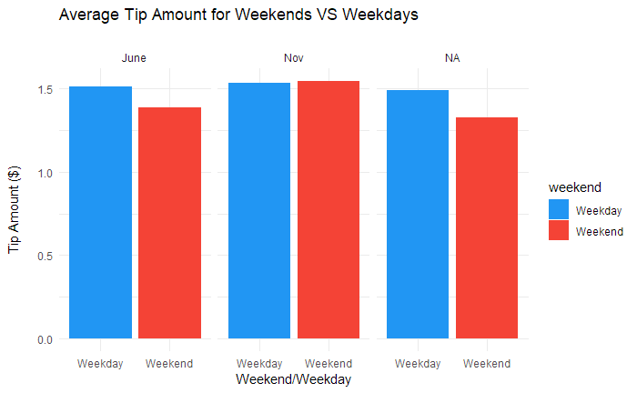

```r
ggplot(trips,aes(x=weekend,y=mean_tip,fill=weekend))+
  geom_bar(stat="identity")+
  facet_wrap(~month)+
  labs(title="Average Tip Amount for Weekends VS Weekdays\n",
       y = "Tip Amount ($)\n",
       x = "Weekend/Weekday")+
  scale_fill_material()+
  theme_minimal()
```

```r
trip_new %>% group_by(pickup_hour) %>% summarise(mean_tip = mean(tip_amount))%>%
  ungroup()%>%
  ggplot(aes(x=pickup_hour,y=mean_tip))+
  geom_point(color="#1565c0")+
  geom_line(color="#1565c0")+
  labs(title="Average Tip Amount by Pickup Hour\n",
       y = "Tip Amount ($)\n",
       x = "Pickup Hour")+
  theme_minimal()
```

[output not shown]

I am also interested in the number of passengers in the taxi. Would that impact the tip amount? So I first count the distribution of passenger number and I found out most people ride taxi alone.

When four people are riding in a taxi, they give the least tip. But when the person is riding taxi alone, the tip amount is very generous.

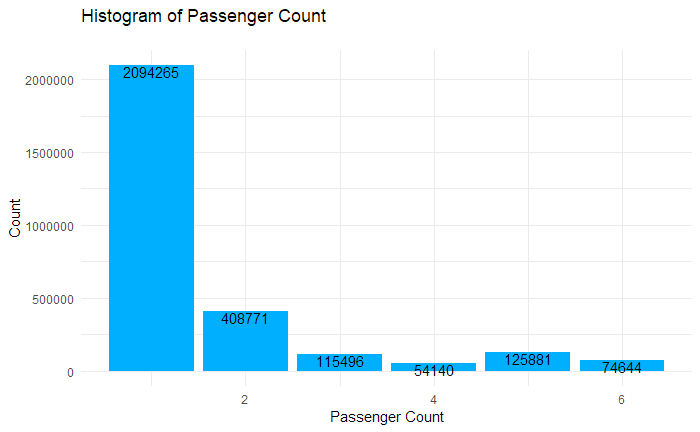

```r
#passenger count
ggplot(trip_new,aes(passenger_count))+
  geom_bar(fill="#00b0ff")+
  geom_text(stat='count',aes(label=..count..),vjust=1)+
  labs(title="Histogram of Passenger Count\n",
       y = "Count",
       x = "Passenger Count")+
  theme_minimal()
```

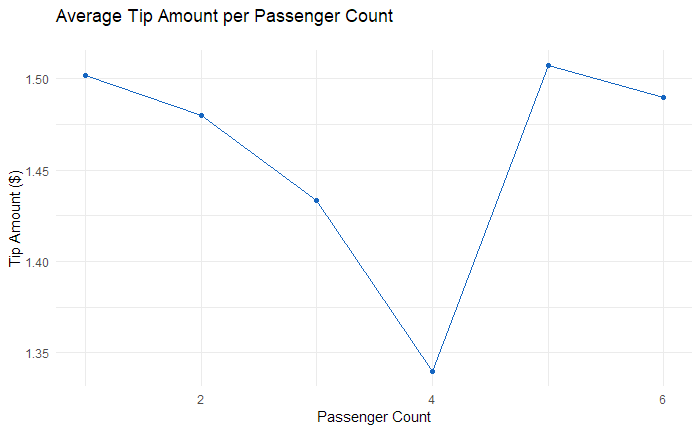

```r
trip_new %>% group_by(passenger_count) %>%
  summarise(mean_tip = mean(tip_amount)) %>%
  ungroup()%>%
ggplot(aes(x=passenger_count,y=mean_tip))+
  geom_point(color="#1565c0")+
  geom_line(color="#1565c0")+
  labs(title="Average Tip Amount per Passenger Count\n",
       y = "Tip Amount ($)",
       x = "Passenger Count")+
  theme_minimal()
```

I think there might be patterns for certain days in a month. So I plot the average tip amount for each day in a month for March, June and November.

I noticed that we actually do not have data for everyday. For example, we do not have much data in the end of a month.

The tip distribution is approximately very similar in a month. Therefore, we should move to the next feature.

```r
trip_new %>% group_by(month,day) %>%
  mutate(n=n())%>%
  filter(n>5)%>%
  summarise(mean_tip=mean(tip_amount))%>%
  ungroup()%>%
  ggplot(aes(x=day,y=mean_tip,fill=month))+
  geom_bar(stat="identity")+
  facet_wrap(~month)+
  scale_fill_material()+
  labs(title = "Average Tip Amount per Day in a Month\n",
       y = "Tip Amount ($)\n",
       x = "Day")+
  theme_minimal()
```

[output not shown]

Another attribute that could be related to tip amount is trip_distance. Since we calculate the fare amount based on trip distance and calculate tip as certain percent of fare amount. So I plot trip_distance vs average tip amount and add a trend line to show the trend.

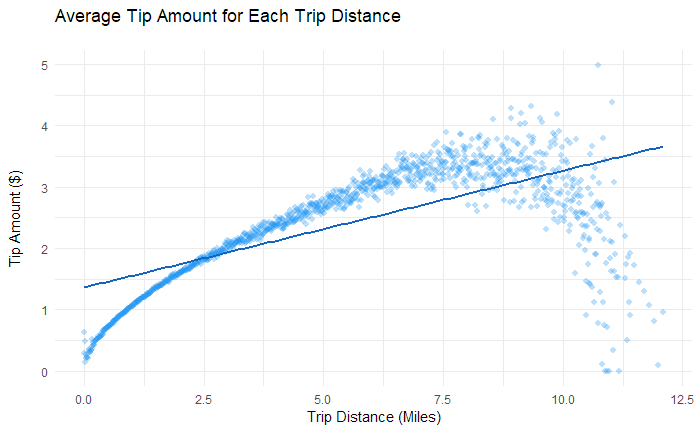

```r
trip_new %>% group_by(trip_distance)%>%
  mutate(n=n())%>%
  filter(n>5)%>%
  summarise(mean_tip=mean(tip_amount))%>%
  ungroup()%>%
  ggplot(aes(x=trip_distance,y=mean_tip))+
  geom_point2(color="#2196f3",alpha=0.3)+
  stat_smooth(method="lm",se=FALSE,color="#1565c0")+
  labs(title = "Average Tip Amount for Each Trip Distance\n",
       y = "Tip Amount ($)\n",
       x = "Trip Distance (Miles)")+
  theme_minimal()
```

```r
#Remove outliers with >10 miles trip distance
trip_new <- trip_new %>% filter(trip_distance <= 10)
```

```r
trip_new %>% group_by(duration)%>%
  mutate(n=n())%>%
  filter(n > 5)%>%
  summarise(mean_tip=mean(tip_amount))%>%
  ungroup()%>%
  ggplot(aes(x=duration,y=mean_tip))+
  geom_point2(color="#2196f3",alpha=0.5)+
  stat_smooth(method="lm",se=FALSE,color="#1565c0")+
  labs(title="Average Tip Amount for Each Trip Duration\n",
       y = "Tip Amount ($)\n",
       x = "Trip Duration (Min)")+
  theme_minimal()
```

[output not shown]

## Feature Selection

Inspecting the correlation plot would be a good start for feature selection. We want to explore if the features are mutually highly correlated, if they are, we need to drop the features.

By exploring the correlation plot, I noticed that total_amount and fare_amount are highly correlated and they both have correlation higher than 0.7. Therefore, I will drop these two features.

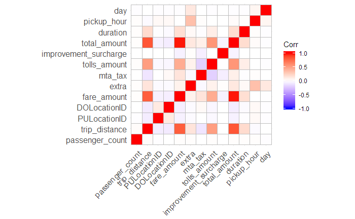

```r
#correlation plot
t <- trip_new %>% select(-c(VendorID,
                               tpep_pickup_datetime,
                               tpep_dropoff_datetime,
                               RatecodeID,
                               store_and_fwd_flag,
                               payment_type,
                               month,
                               tip_amount,
                               weekday))
corr <- cor(t)
ggcorrplot(corr)
```

```r
#drop features with correlation higher than 0.7
highcorr <- findCorrelation(corr,0.7)
names(t)[highcorr]
```

```
[1] "total_amount" "fare_amount"
```

```r
trip_new <- trip_new %>% select(-c(total_amount,fare_amount))
```

Because we have used the pickup and dropoff column to calculate the trip duration,then we can drop those two columns. Then I used the variable importance function to exclude some low importance features from the dataset: VendorID,RatecodeID, store_and_fwd_flag,passenger_count, improvement_surcharge, mta_tax, PULocationID, DOLocationID, extra, and weekday.

```r
trip_new <- trip_new %>% select(-c(tpep_pickup_datetime,tpep_dropoff_datetime))
```

[output not shown]

## Core features

```r
names(trip_new%>%select(-tip_amount))
```

[output not shown]

# Model Building

## Model Fitting

I choose the linear regression model because it takes little time to train and the dataset is huge. I am running the model on a 16GB RAM laptop, so it would take a huge amount time to train other models (randomforest).

```r
#set seed
set.seed(1026)
#split train and set
trip_new <- na.omit(trip_new)
train_sample <- sample(nrow(trip_new), size = nrow(trip_new)*0.66)
train_new <-  trip_new[train_sample,]
test_new <-  trip_new[-train_sample,]
#Removing outliers for train set
train_new <- train_new %>% group_by(month) %>%
  mutate(

         avg_dur = mean(duration),
         sd_dur = sd(duration)) %>%
  filter(

         duration < avg_dur + 1.5*sd_dur,
         duration > avg_dur - 1.5*sd_dur) %>%
  select(-c(avg_dur,sd_dur))%>%
  ungroup()
#original model
model <- lm(tip_amount~.,data=train_new)
summary(model)
```

```
Call:
lm(formula = tip_amount ~ ., data = train_new)

Residuals:
    Min      1Q  Median      3Q     Max
-156.20   -0.50    0.00    0.59  347.98

Coefficients:
                Estimate Std. Error  t value Pr(>|t|)
(Intercept)    1.2846281  0.0037549  342.119  < 2e-16 ***
trip_distance  0.2411606  0.0005691  423.787  < 2e-16 ***
payment_type2 -2.5443085  0.0025540 -996.215  < 2e-16 ***
payment_type3 -2.7126248  0.0170610 -158.996  < 2e-16 ***
payment_type4 -2.8549247  0.0319409  -89.382  < 2e-16 ***
payment_type5 -3.4700258  1.6802288   -2.065   0.0389 *
tolls_amount   0.1651774  0.0007790  212.032  < 2e-16 ***
monthMar       0.0245811  0.0028748    8.551  < 2e-16 ***
monthNov       0.0191882  0.0029713    6.458 1.06e-10 ***
duration       0.0378160  0.0001657  228.187  < 2e-16 ***
pickup_hour    0.0053822  0.0001800   29.908  < 2e-16 ***
day           -0.0009984  0.0002393   -4.172 3.02e-05 ***
---
Signif. codes:  0 ‘***’ 0.001 ‘**’ 0.01 ‘*’ 0.05 ‘.’ 0.1 ‘ ’ 1

Residual standard error: 1.68 on 2055759 degrees of freedom
Multiple R-squared:  0.5567,    Adjusted R-squared:  0.5567
F-statistic: 2.347e+05 on 11 and 2055759 DF,  p-value: < 2.2e-16
```

```r
#cook distance
cooksd <- cooks.distance(model)
#use cook distance to remove outliers
influential <- as.numeric(names(cooksd)[(cooksd > (4/nrow(train_new)))])
train_screen <- train_new[-na.omit(influential),]
#adjusted model
model_adjusted <- lm(tip_amount~.,data=train_screen)
summary(model_adjusted)
```

```
Call:
lm(formula = tip_amount ~ ., data = train_screen)

Residuals:
    Min      1Q  Median      3Q     Max
-9.2050 -0.3728  0.0518  0.4788  6.1480

Coefficients:
                Estimate Std. Error   t value Pr(>|t|)
(Intercept)    1.079e+00  2.043e-03   528.093  < 2e-16 ***
trip_distance  2.351e-01  4.553e-04   516.322  < 2e-16 ***
payment_type2 -2.141e+00  1.352e-03 -1583.670  < 2e-16 ***
payment_type3 -2.339e+00  1.319e-02  -177.259  < 2e-16 ***
payment_type4 -2.670e+00  3.759e-02   -71.018  < 2e-16 ***
tolls_amount   3.177e-01  8.504e-04   373.641  < 2e-16 ***
monthMar       1.445e-02  1.516e-03     9.535  < 2e-16 ***
monthNov       9.585e-03  1.570e-03     6.105 1.03e-09 ***
duration       4.268e-02  1.057e-04   403.899  < 2e-16 ***
pickup_hour    5.701e-03  9.501e-05    60.009  < 2e-16 ***
day           -1.373e-03  1.287e-04   -10.673  < 2e-16 ***
---
Signif. codes:  0 ‘***’ 0.001 ‘**’ 0.01 ‘*’ 0.05 ‘.’ 0.1 ‘ ’ 1

Residual standard error: 0.8636 on 1948394 degrees of freedom
Multiple R-squared:  0.7503,    Adjusted R-squared:  0.7503
F-statistic: 5.854e+05 on 10 and 1948394 DF,  p-value: < 2.2e-16
```

## Model Evaluation

- RMSE: indicates the absolute fit of the model to the data: how close the observed data points are to the model’s predicted values
- RMSE/mean: RMSE is measured as the same units as the response variable. So we can divide the RMSE by the mean of response and interpret it in terms of percentage of the mean.
- R-squared: indicates how much percent of variance can be explained by the model

```r
#Compute RMSE for base line model
pd_base <- predict(model,test_new)
RMSE_base <- sqrt(sum((pd_base - test_new$tip_amount)^2)/length(pd_base))
RMSE_mean_base <- RMSE_base/mean(test_new$tip_amount)
R_base <- summary(model)$r.squared
#Compute RMSE for adjusted model
pd_lm <- predict(model_adjusted,test_new)
RMSE_lm <- sqrt(sum((pd_lm - test_new$tip_amount)^2)/length(pd_lm))
RMSE_mean_lm <- RMSE_lm/mean(test_new$tip_amount)
R_lm <- summary(model_adjusted)$r.squared
df <- tibble(Model=c("Baseline","Adjusted"),RMSE=c(RMSE_base,RMSE_lm),RMSE_mean=c(RMSE_mean_base,RMSE_mean_lm),R_squared=c(R_base,R_lm))
kable(df,caption="Model Evaluation")
```

| Model | RMSE | RMSE_mean | R_squared |
| --- | --- | --- | --- |
| Baseline | 2.631411 | 1.403652 | 0.5567472 |
| Adjusted | 2.848361 | 1.519378 | 0.7502972 |

## Model limitation and improvement

The limitation of the linear regression model is that it is sensitive to outliers. Although I have excluded the outliers that I can think of, but there might still be some left. To improve my model, I might want to try use randomforest instead (if my computer allows). The randomforest model is strong with outliers, irrelevant variables, continuous and discrete variables.

## Turning model into API

I will first save my model to hard disk. Then I will write a function to import the data and predict it using the model, and save this function as R script. After that, I will use the plumber package to deploy the R script. I will also check for input validation, monitoring and security for the API. To scale up the API, I will package up everything in a Docker container and run it.